# Fatal opioid-detected overdoses in Region 5, 2018-2023

This analysis uses accidental/undetermined opioid-detected overdose data from the Connecticut Office of the Chief Medical Examiner.

### Race

The vast majority of decedents are either white, Black or Latine. There is limited information available on the race/ethnicity of other decedents, so they are listed as “other”.

#### 2018

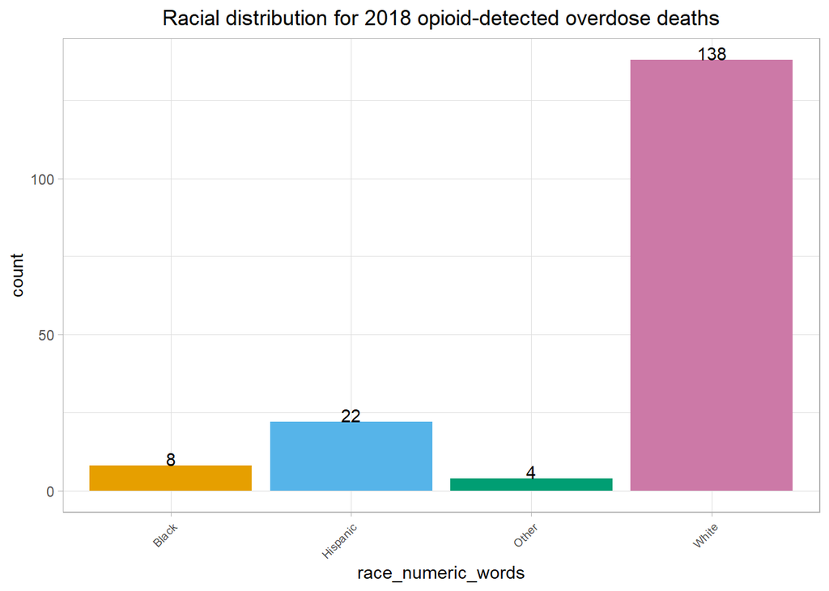

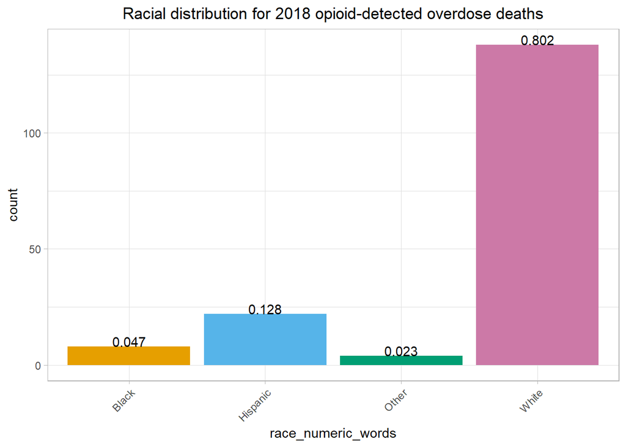

#### 2019

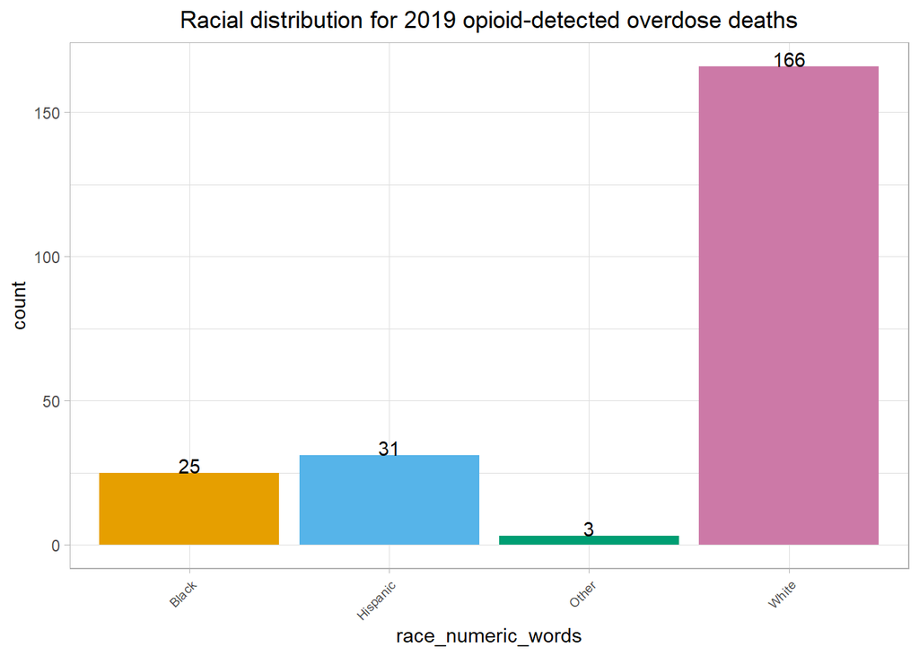

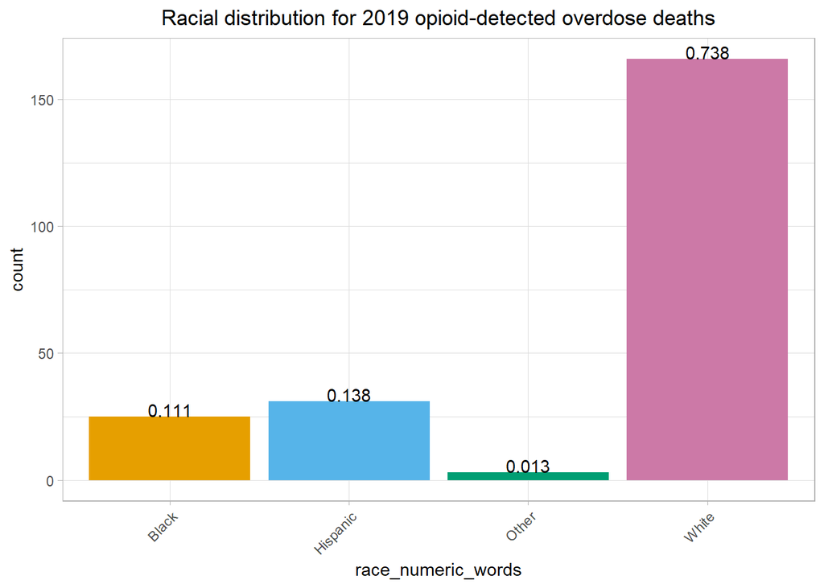

#### 2020

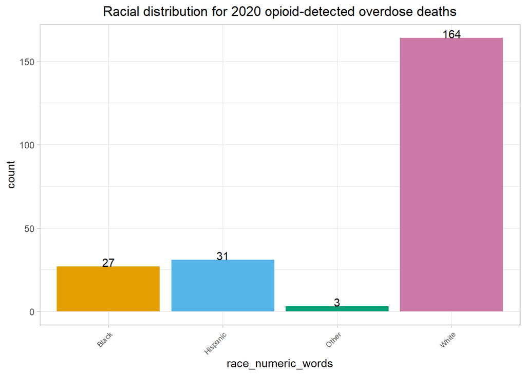

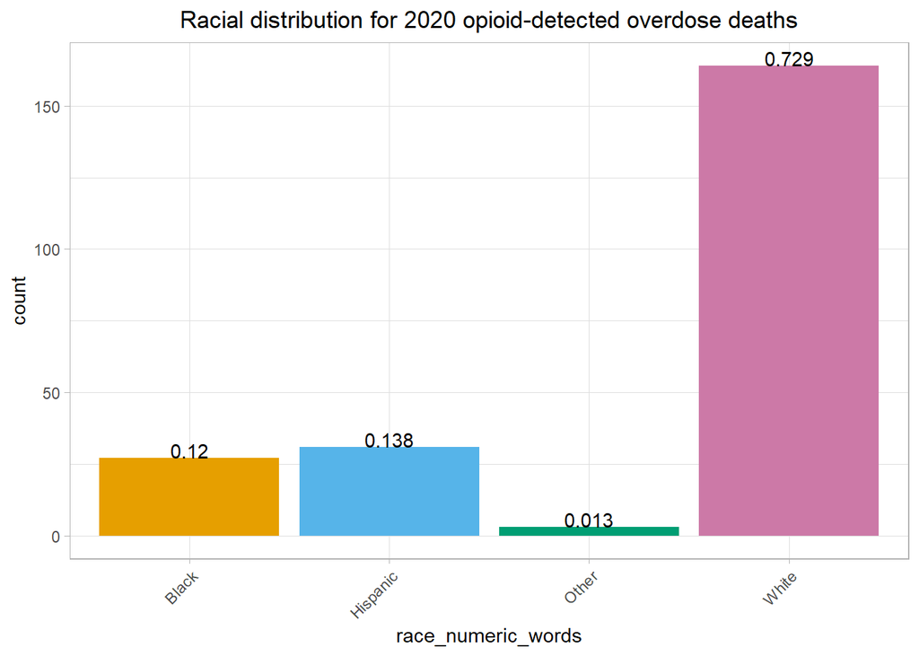

#### 2021

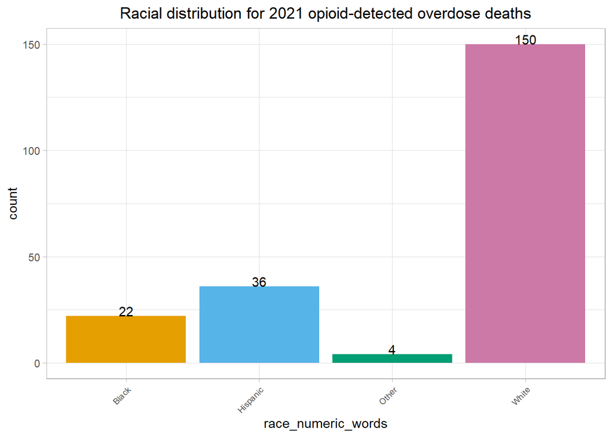

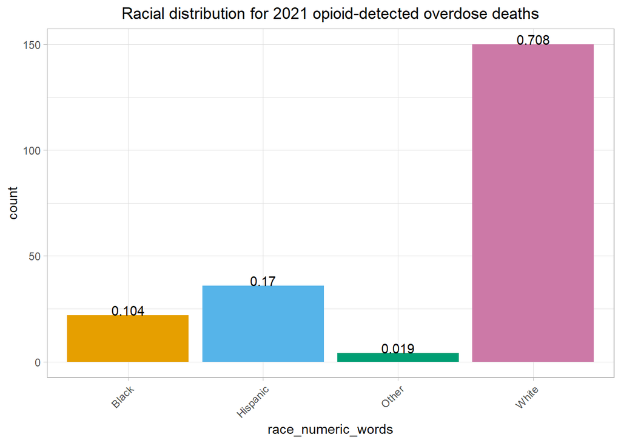

#### 2022

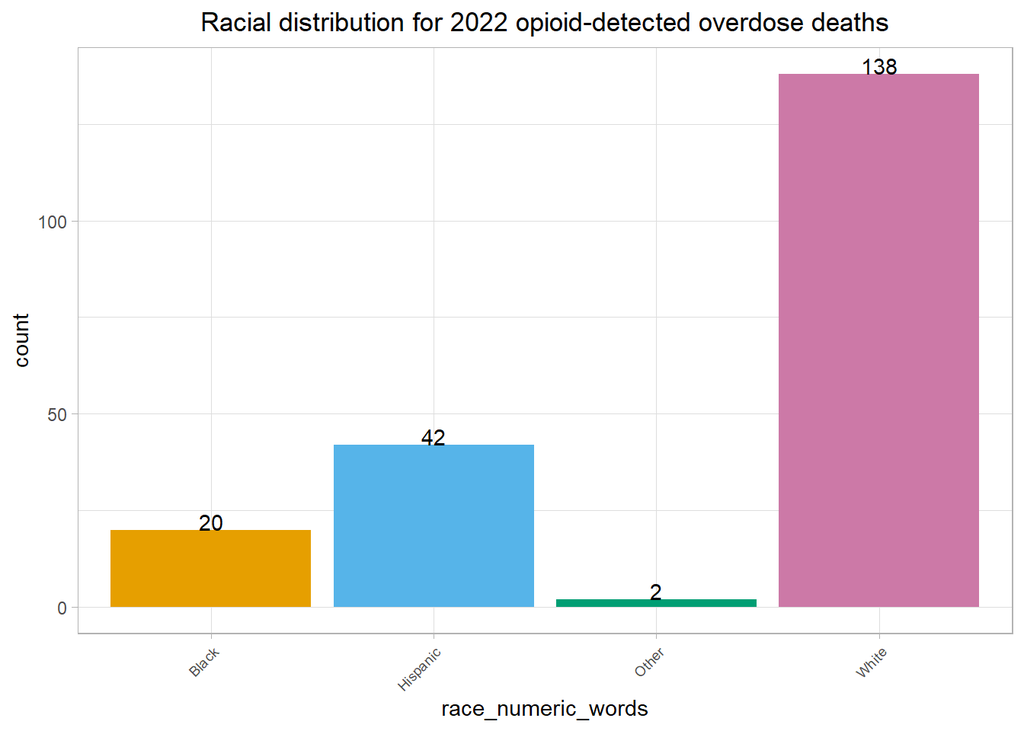

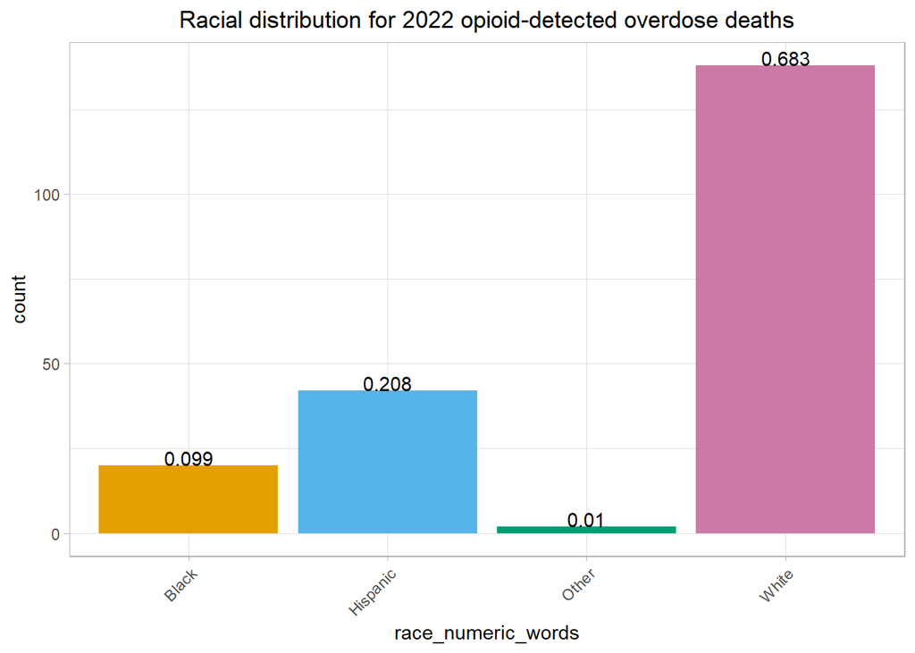

#### 2023

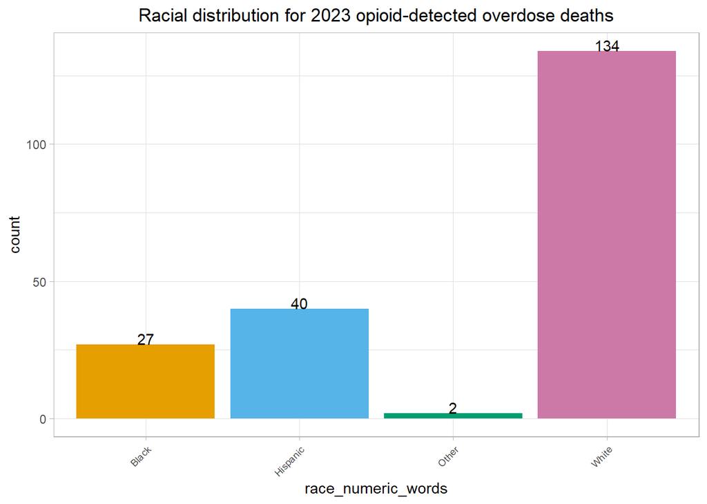

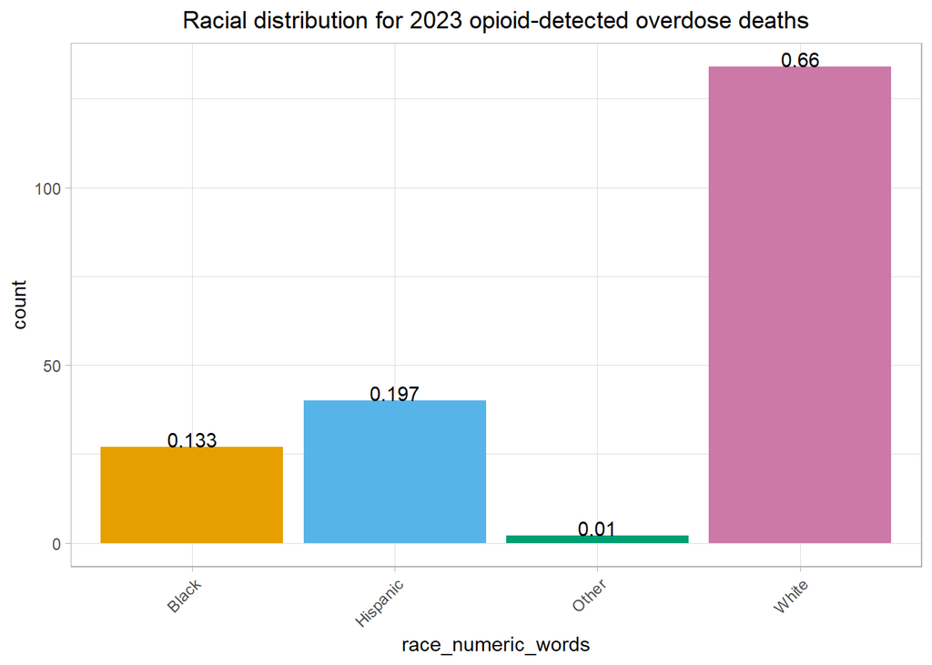

### Sex

CT OCME captures limited information about trans decedents, seemingly from hrt scripts and possibly other scene information/witness statements. Please note that this is almost certainly an undercount of the actual number of trans decedents, since OCME only captures sex by visual inspection and would require witness statements to get information about gender. Even though “MtF” and other trans designators present in the data are not related to sex, I are presenting them for the sake of not obscuring data about trans people and otherwise list this variable as “sex” since OCME seeks to capture sex, not gender. In recent years, OCME has debuted an “X” value for sex which seems to function as a catch-all designator for trans/nonbinary people.

#### 2018

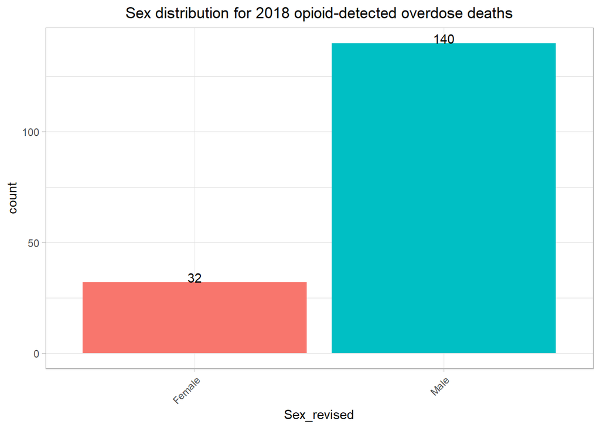

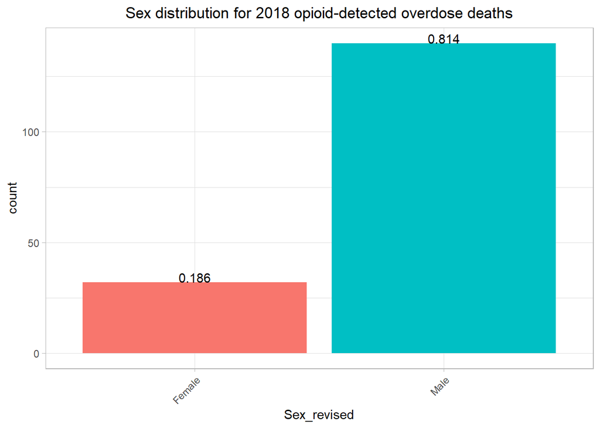

#### 2019

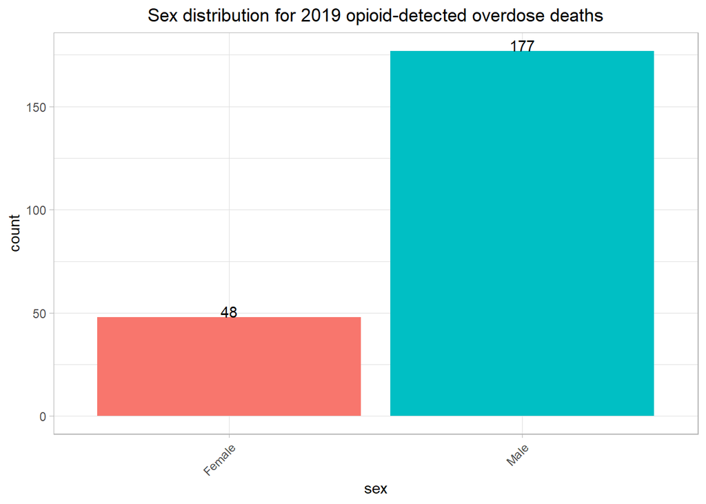

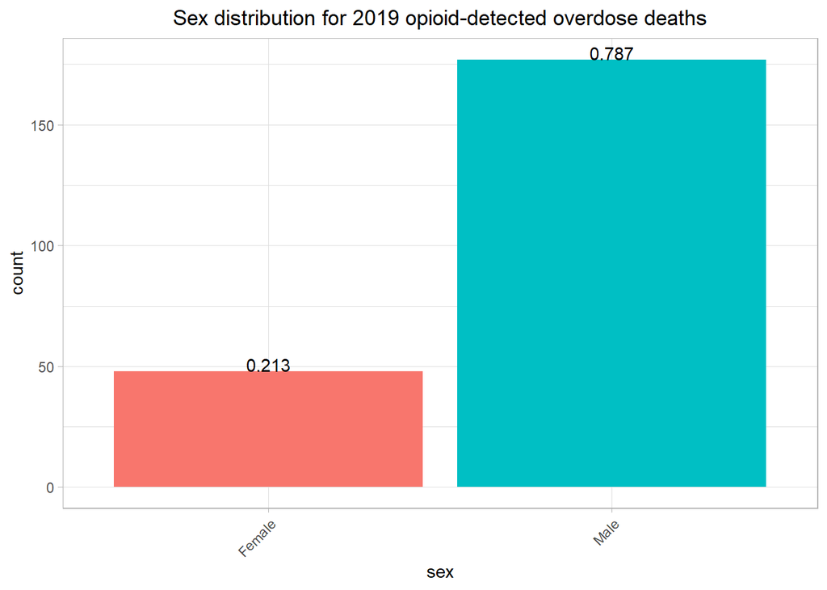

#### 2020

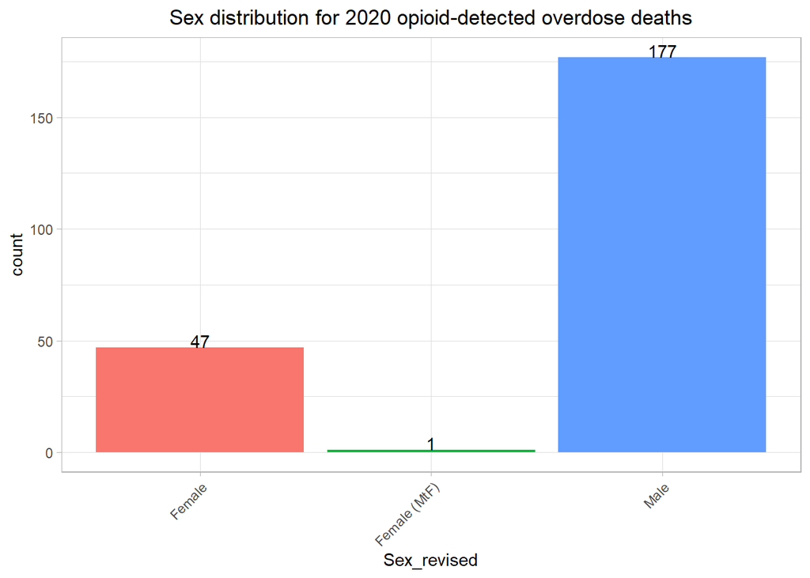

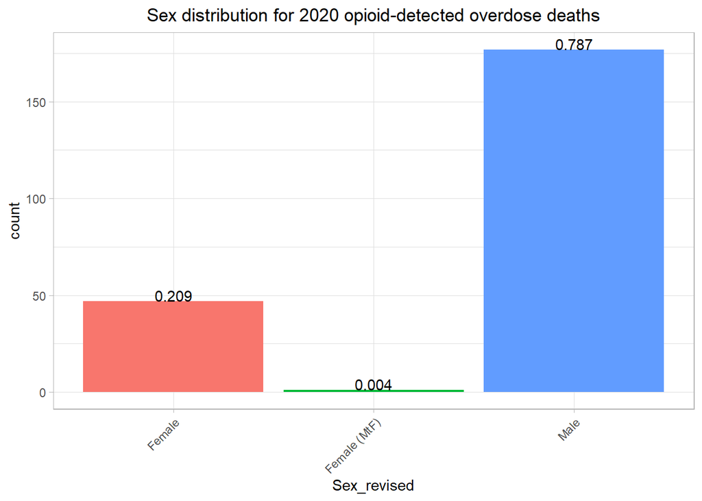

#### 2021

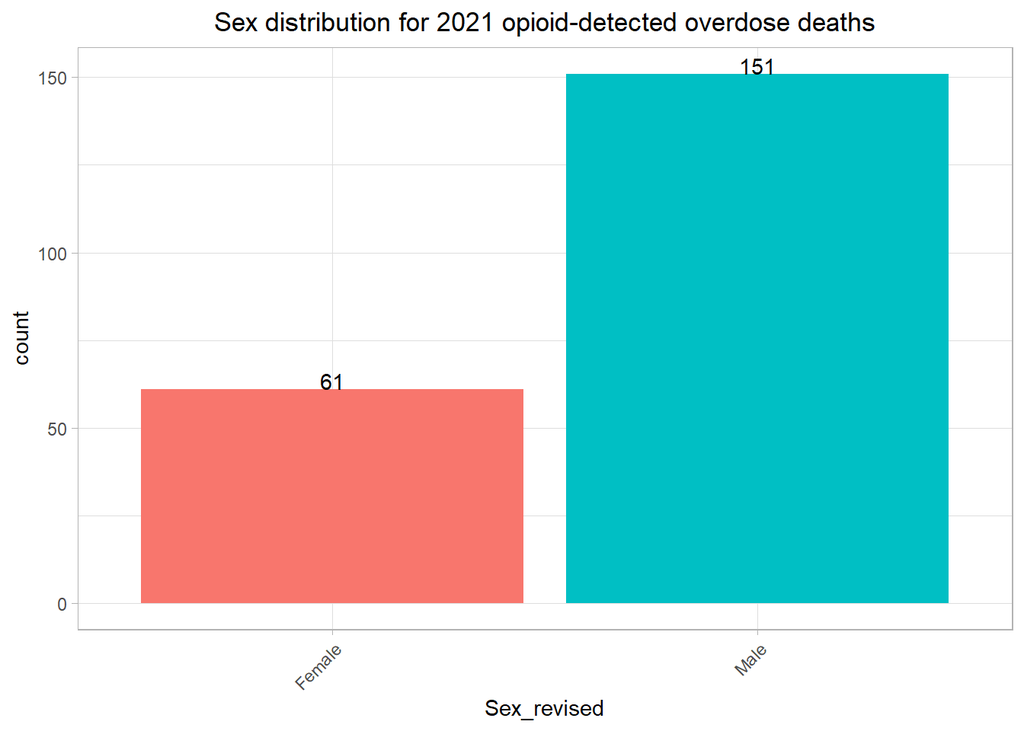

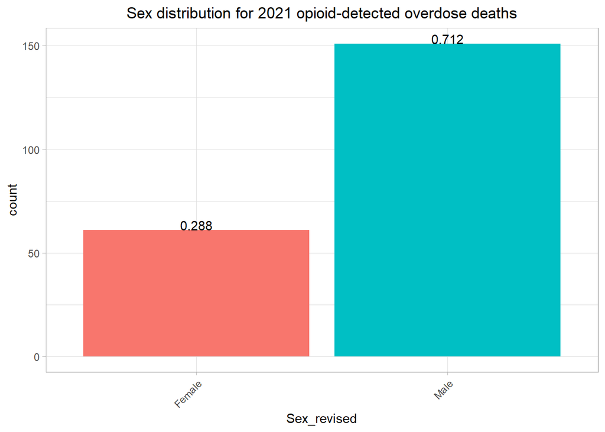

#### 2022

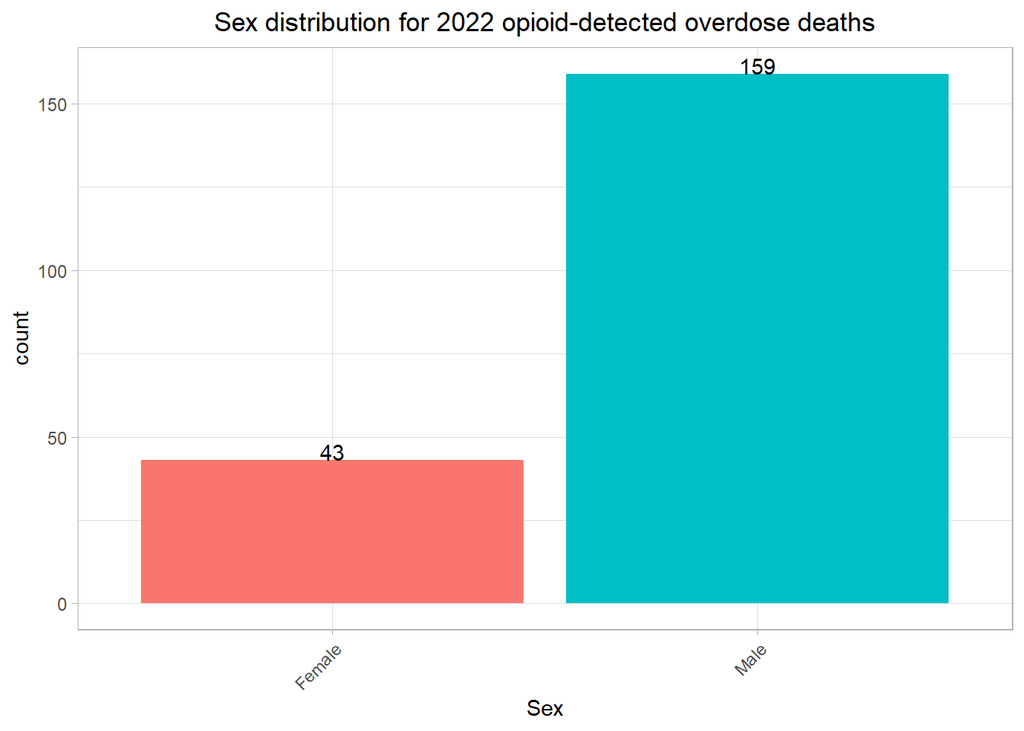

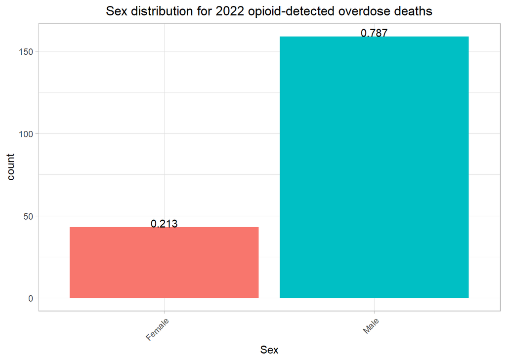

#### 2023

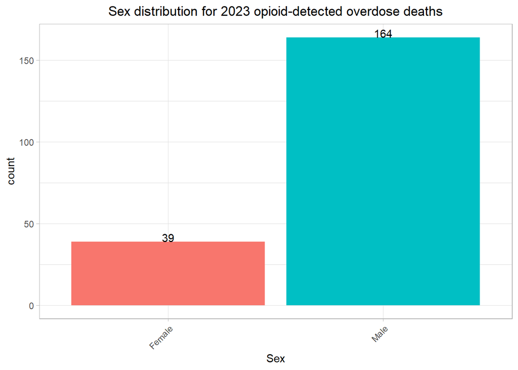

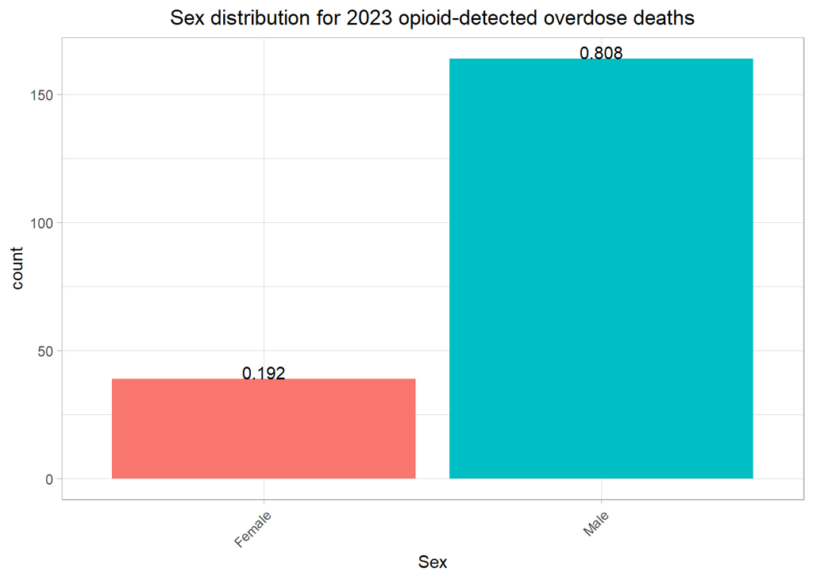

### Race and sex

I create these graphs by combining the information present in the “race” and “sex” variables.

#### 2018

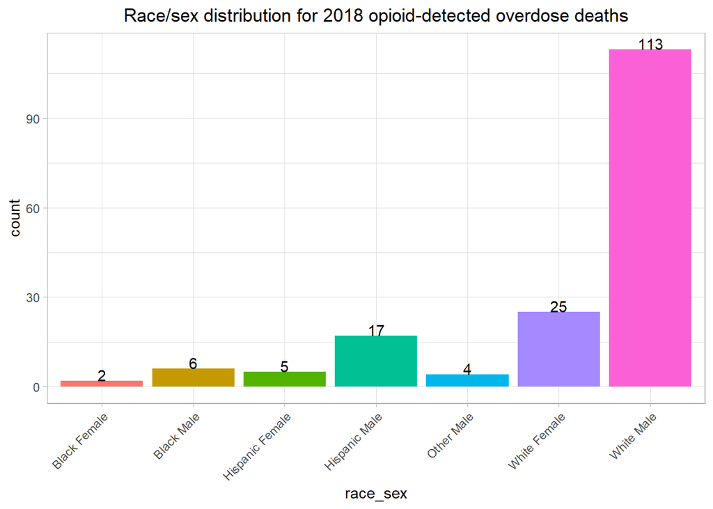

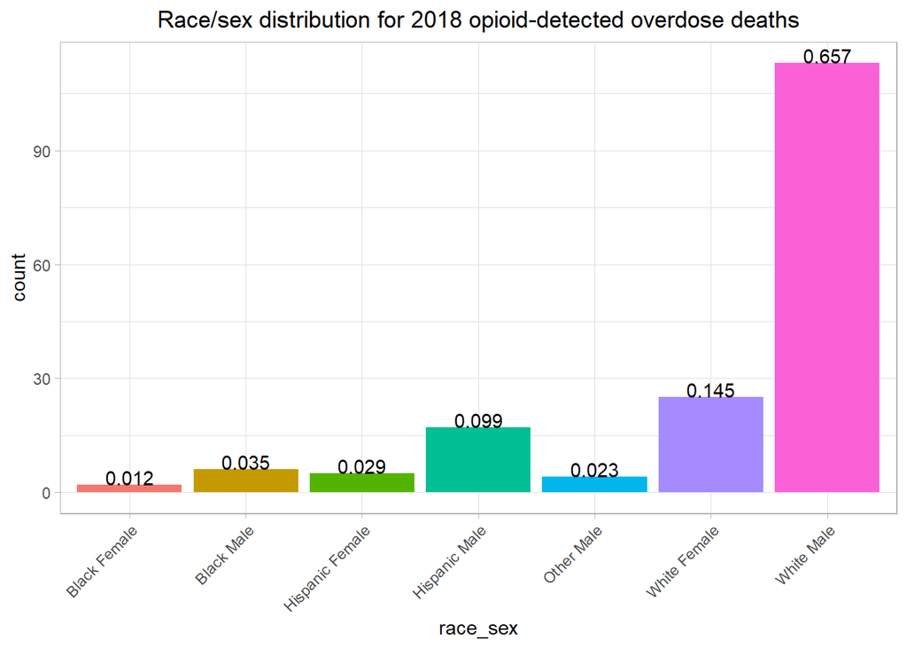

#### 2019

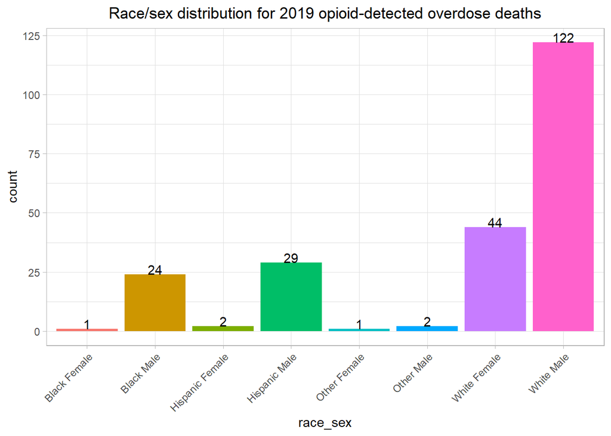

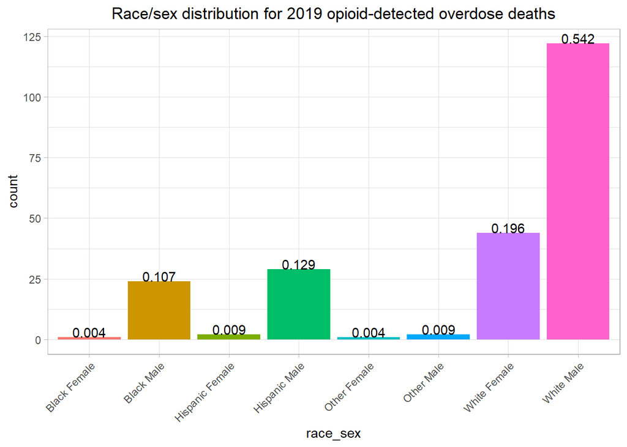

#### 2020

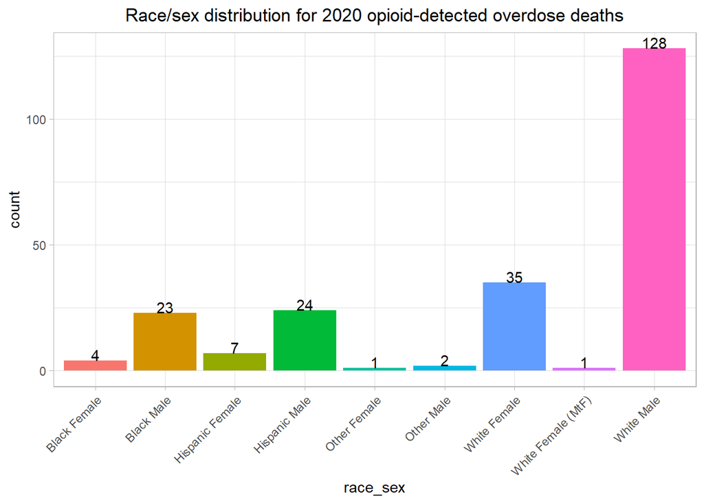

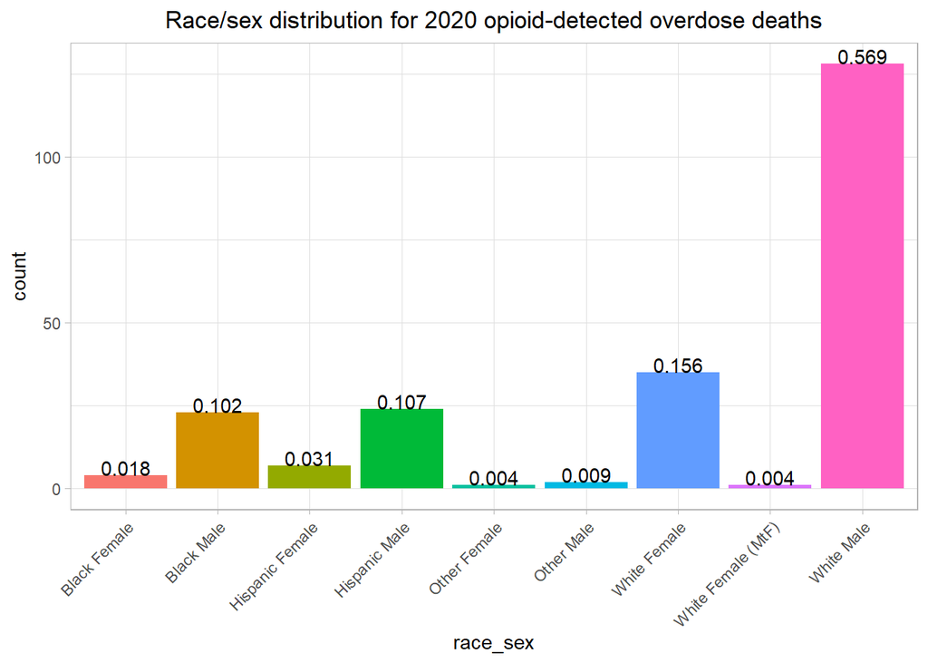

#### 2021

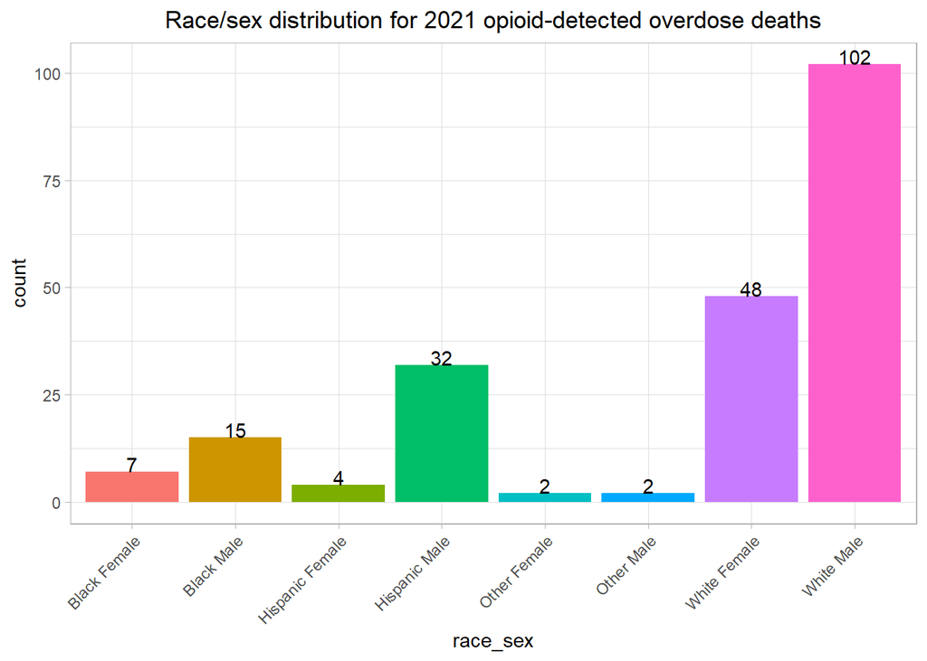

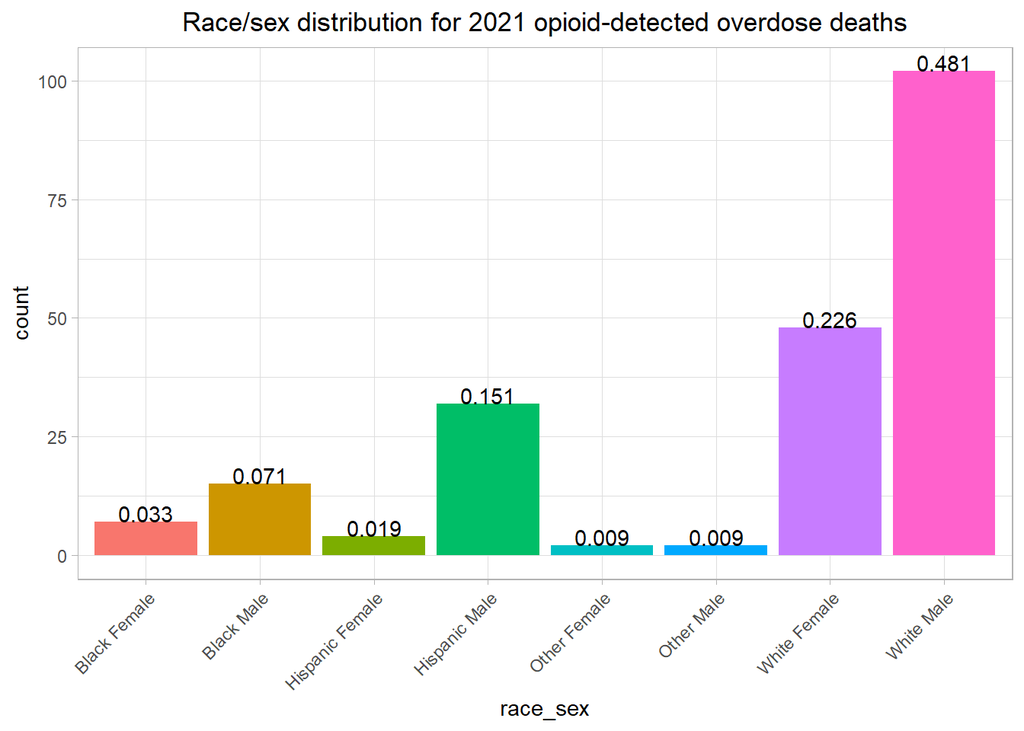